# Project 2: Data Mining, Classification, Prediction

SDS322E

# Mining, Classification, Prediction

## Thao Nguyen, tpn433

### Introduction

The `bechdel` dataset is a combination of the merged `join3` dataset from [Project 1](https://thaophnguyen.github.io/project1/), originally from IMDb, and the `raw_bechdel` dataset from the week of 03/09/21’s tidytuesday on [GitHub](https://github.com/rfordatascience/tidytuesday/tree/master/data/2021/2021-03-09), sourced via Bechdeltest.com API. The `bechdel` dataset works only with movies and contains 7,628 observations from 1970-2020. Its variables include `year`, the year a movie was released, `id`, the movie’s unique IMDb identifier, `rating`, the movie’s Bechdel rating (1 if it passes the first Bechdel criteria, it has at least two named women in it, 2 if it passes the second criteria, those women talk to each other, 3, if it passes the third, the the topic of their conversation is something besides a man, and 0 if it does not pass any of the three criteria), binary variables (`zero`, `one`, `two`, `three`) for whether a movie passed each individual criteria, `runtime`, the length of a movie in minutes, `avgRating`, the movie’s average IMDb rating as of 11/01/2021, `numVotes`, and the number of reviews a movie has on IMDb as of 11/01/2021. Looking at the binary variables `one`, `two`, and `three`, respectively, 6993 observations passed the first criteria 5300 passed the second criteria, and 4581 passed the third.

```r
library(tidyverse)
# bechdel dataset
raw_bechdel <- readr::read_csv("https://raw.githubusercontent.com/rfordatascience/tidytuesday/master/data/2021/2021-03-09/raw_bechdel.csv")
head(raw_bechdel)
```

```
## # A tibble: 6 x 5
##    year    id imdb_id title                                 rating
##   <dbl> <dbl> <chr>   <chr>                                  <dbl>
## 1  1888  8040 0392728 Roundhay Garden Scene                      0
## 2  1892  5433 0000003 Pauvre Pierrot                             0
## 3  1895  6200 0132134 The Execution of Mary, Queen of Scots      0
## 4  1895  5444 0000014 Tables Turned on the Gardener              0
## 5  1896  5406 0000131 Une nuit terrible                          0
## 6  1896  5445 0223341 La fee aux choux                           0
```

```r
# creates binary variables for each bechdel criteria (0 =
# does not meet any, 1 = has at least two named women in it,
# 2 = who talk to each other, 3 = about something besides a
# man.)
raw_bechdel2 <- raw_bechdel %>% mutate(zero = ifelse(rating ==
    0, 1, 0)) %>% mutate(one = ifelse(rating >= 1, 1, 0)) %>%
    mutate(two = ifelse(rating >= 2, 1, 0)) %>% mutate(three = ifelse(rating ==
    3, 1, 0)) %>% select(-2) %>% rename(id = "imdb_id")

# add 'tt' to imdb id
raw_bechdel2$id <- sub("^", "tt", raw_bechdel2$id)

# merged dataset from project 1
basics_init <- read_tsv("https://datasets.imdbws.com/title.basics.tsv.gz")
ratings_init <- read_csv("https://datasets.imdbws.com/title.ratings.tsv.gz")
episode_init <- read_tsv("https://datasets.imdbws.com/title.episode.tsv.gz")
ratings_tidy <- ratings_init %>% separate(`tconst\taverageRating\tnumVotes`,
    into = c("id", "avgRating", "numVotes"), sep = "\\s")

basics_tidy <- basics_init %>% rename(id = 1, type = 2, title = 3,
    startYear = 6, endYear = 7, runtime = 8)

episode_tidy <- episode_init %>% rename(id = 1, showId = 2, seasonNum = 3,
    epNum = 4)

basics_tidy2 <- basics_tidy %>% select(id, title) %>% rename(showId = 1)

basics_tidy %>% summarise(n = n())
```

```
## # A tibble: 1 x 1
##         n
##     <int>
## 1 6928345
```

```r
basics_tidy %>% summarise(n_distinct(id))
```

```
## # A tibble: 1 x 1
##   `n_distinct(id)`
##              <int>
## 1          6928345
```

```r
ratings_tidy %>% summarise(n = n())
```

```
## # A tibble: 1 x 1
##         n
##     <int>
## 1 1193488
```

```r
ratings_tidy %>% summarise(n_distinct(id))
```

```
## # A tibble: 1 x 1
##   `n_distinct(id)`
##              <int>
## 1          1193488
```

```r
episode_tidy %>% summarise(n = n())
```

```
## # A tibble: 1 x 1
##         n
##     <int>
## 1 6334384
```

```r
episode_tidy %>% summarise(n_distinct(id))
```

```
## # A tibble: 1 x 1
##   `n_distinct(id)`
##              <int>
## 1          6334384
```

```r
join1 <- basics_tidy %>% right_join(ratings_tidy, by = "id")
join1 %>% summarise(n = n())
```

```
## # A tibble: 1 x 1
##         n
##     <int>
## 1 1193488
```

```r
join1 %>% summarise(n_distinct(id))
```

```
## # A tibble: 1 x 1
##   `n_distinct(id)`
##              <int>
## 1          1193488
```

```r
join2 <- join1 %>% left_join(episode_tidy, by = "id")
join2 %>% summarise(n = n())
```

```
## # A tibble: 1 x 1
##         n
##     <int>
## 1 1193488
```

```r
join2 %>% summarise(n_distinct(id))
```

```
## # A tibble: 1 x 1
##   `n_distinct(id)`
##              <int>
## 1          1193488
```

```r
join3 <- join2 %>% left_join(basics_tidy2, by = "showId")

# keeps only movie types, remove adult films, remove tv
# show-related columns
movie <- join3 %>% filter(type == "movie") %>% filter(isAdult ==
    0) %>% select(-"originalTitle", -"isAdult") %>% rename(title = "title.x") %>%
    mutate_all(funs(str_replace(., "\\\\N", NA_character_))) %>%
    select(1:4, 6:9)

# makes numerical columns numeric
cols_num <- c(4:5, 7:8)
movie[cols_num] <- sapply(movie[cols_num], as.numeric)

# left joins raw_bechdel2 and movie dataset
bechdel <- left_join(raw_bechdel2, movie, by = "id")
bechdel <- bechdel %>% select(-"type") %>% select(-"title.y") %>%
    select(-"startYear") %>% rename(title = "title.x") %>% filter(year >=
    1970)

bechdel %>% filter(one == 1) %>% nrow()
```

```
## [1] 6993
```

```r
bechdel %>% filter(two == 1) %>% nrow()
```

```
## [1] 5300
```

```r
bechdel %>% filter(three == 1) %>% nrow()
```

```
## [1] 4581
```

```r
# removes instances of duplicate or missing ids
bechdel <- bechdel %>% distinct(id, .keep_all = TRUE) %>% filter(!is.na(id))
```

### Cluster Analysis

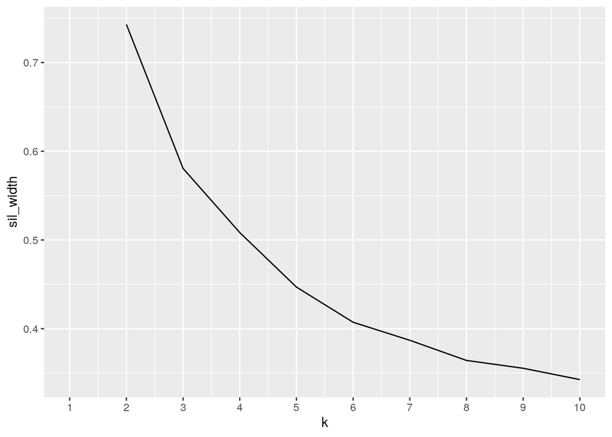

```r
library(cluster)
library(GGally)

bechdel$three <- as.character(as.numeric(bechdel$three))

dat2 <- bechdel %>% mutate_if(is.character, as.factor) %>% column_to_rownames("id") %>%
    select(year, avgRating, numVotes, three)

# computes gower dissimilarities
gower1 <- daisy(dat2, metric = "gower")

# use silhouette width to pick number of pam clusters
sil_width <- vector()
for (i in 2:10) {
    pam_fit <- pam(gower1, diss = TRUE, k = i)
    sil_width[i] <- pam_fit$silinfo$avg.width
}
ggplot() + geom_line(aes(x = 1:10, y = sil_width)) + scale_x_continuous(name = "k",
    breaks = 1:10)  # optimal number of clusters is 2
```

```r
# perform clustering with pam
pam3 <- pam(gower1, k = 2, diss = T)
pam3
```

```
## Medoids:
##      ID
## [1,] "3937" "tt0800308"
## [2,] "4097" "tt0924129"
## Clustering vector:
## tt0065988 tt0066491 tt0066227 tt0065421 tt0067713 tt0066549 tt0065531 tt0065772
##         1         1         2         2         1         1         1         2
## tt0066279 tt0066109 tt0067961 tt0066011 tt0066122 tt0188484 tt0066473 tt0064165
##         2         1         2         1         1         2         1         1
## tt0065571 tt0066164 tt0065377 tt0064177 tt0066207 tt0065528 tt0066518 tt0065856
##         2         2         2         1         2         2         2         1
## tt0065649 tt0067355 tt0065611 tt0064806 tt0065134 tt0065488 tt0065569 tt0065466
##         2         1         2         1         2         1         1         2
## tt0065073 tt0065724 tt0066327 tt0065449 tt0065854 tt0067128 tt0066817 tt0066380
##         2         2         1         2         2         1         2         2
## tt0067185 tt0067972 tt0067483 tt0067881 tt0067451 tt0067741 tt0067919 tt0067690
##         2         1         2         2         2         1         2         2
## tt0067992 tt0067023 tt0067116 tt0067637 tt0067541 tt0067927 tt0067418 tt0067367
##         1         1         1         2         1         1         1         2
## tt0066730 tt0067482 tt0067328 tt0067065 tt0066765 tt0066995 tt0068675 tt0067439
##         1         2         1         1         1         1         1         2
## tt0067810 tt0067372 tt0067820 tt0067411 tt0249577 tt0066921 tt0067800 tt0066824
##         1         1         2         2         1         1         1         1
## tt0067633 tt0067341 tt0067959 tt0067445 tt0066434 tt0067309 tt0067148 tt0067588
##         2         2         1         1         1         2         2         2
## tt0066993 tt0066763 tt0066728 tt0066808 tt0067322 tt0067402 tt0066919 tt0068473
##         2         1         1         1         2         2         1         1
## tt0067977 tt0069089 tt0068762 tt0069113 tt0068828 tt0201820 tt0070694 tt0068816
##         1         2         1         1         2         2         2         1
## tt0069442 tt0066798 tt0069467 tt0068611
##         2         1         2         2
##  [ reached getOption("max.print") -- omitted 7520 entries ]
## Objective function:
##      build       swap
## 0.08045794 0.08039501
##
## Available components:
## [1] "medoids"    "id.med"     "clustering" "objective"  "isolation"
## [6] "clusinfo"   "silinfo"    "diss"       "call"
```

```r
bechdel %>% filter(id == "tt0800308")
```

```
## # A tibble: 1 x 12
##    year id    title rating  zero   one   two three runtime genres avgRating
##   <dbl> <chr> <chr>  <dbl> <dbl> <dbl> <dbl> <chr>   <dbl> <chr>      <dbl>
## 1  2008 tt08… Appa…      1     0     1     0 0         115 Actio…       6.7
## # … with 1 more variable: numVotes <dbl>
```

```r
bechdel %>% filter(id == "tt0924129")
```

```
## # A tibble: 1 x 12
##    year id    title rating  zero   one   two three runtime genres avgRating
##   <dbl> <chr> <chr>  <dbl> <dbl> <dbl> <dbl> <chr>   <dbl> <chr>      <dbl>
## 1  2009 tt09… Cros…      3     0     1     1 1         113 Crime…       6.7
## # … with 1 more variable: numVotes <dbl>
```

```r
# calculate avg sil width
pam3$silinfo$avg.width
```

```
## [1] 0.7429889
```

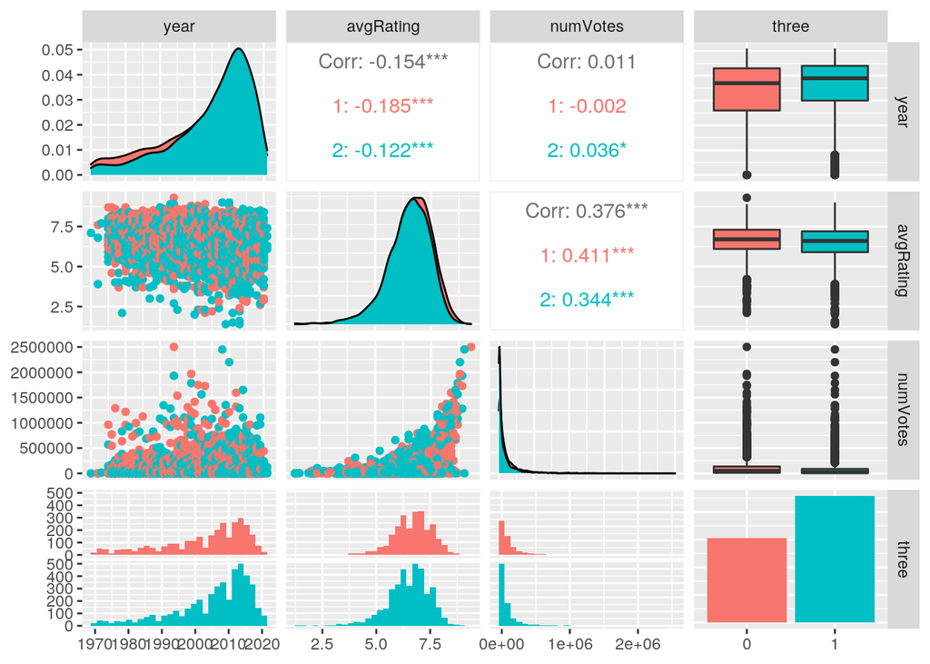

```r
# visualization
ggpairs(as.data.frame(dat2), columns = 1:4, aes(color = as.factor(pam3$clustering)))
```

I performed PAM clustering based on gower dissimilarities on the numeric variables `year`, `avgRating`, and `numVotes`, along with the categorical variable `three`, whether or not an observation passes all three Bechdel test criteria. After getting a distance matrix by computing the gower dissimilarities, I picked the number of clusters to run the PAM with using the highest average silhouette width, which was 2. Running the PAM cluster analysis with 2 clusters showed that the 2008 movie “Appaloosa” was representative of the first cluster while the 2009 movie “Crossing Over” was representative of the second cluster. The average silhouette width is 0.74, indicating that a strong goodness of fit of the cluster solution. Looking at the visualization using ggpairs, the two clusters are very similar and have a lot of overlap in the three numeric variables but are very distinct in the Bechdel test variable.

### Dimensionality Reduction with PCA

```r
dat3 <- bechdel %>% select(id, year, avgRating, numVotes)
dat3_nums <- dat3 %>% select_if(is.numeric) %>% scale
rownames(dat3_nums) <- dat3$id
dat3_pca <- princomp(na.omit(dat3_nums), cor = T)

summary(dat3_pca, loadings = T)
```

```
## Importance of components:
##                           Comp.1    Comp.2    Comp.3
## Standard deviation     1.1841662 1.0039188 0.7680479
## Proportion of Variance 0.4674165 0.3359510 0.1966325
## Cumulative Proportion  0.4674165 0.8033675 1.0000000
##
## Loadings:
##           Comp.1 Comp.2 Comp.3
## year       0.253  0.925  0.282
## avgRating -0.710         0.704
## numVotes  -0.657  0.378 -0.652
```

```r
# calculate eigen values to determine how many pcs to keep
eigval <- dat3_pca$sdev^2
eigval
```

```
##    Comp.1    Comp.2    Comp.3
## 1.4022495 1.0078529 0.5898976
```

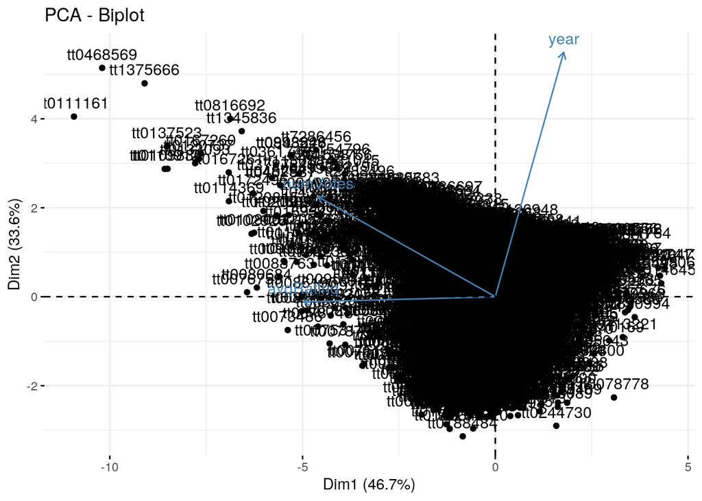

```r
# biplot combining plot with pc scores with respect to the
# first 2 pcs and loadings plot
library(factoextra)
fviz_pca_biplot(dat3_pca)
```

```r
# highest on PC1
```